# **Attrition rate analysis**

Sohom Das

31/12/2021

### Problem Statement

A large multinational organisation, employs at any given point of time, around 4000 employees. Every year, around 15% of the company’s employees quit and must be replaced with new people. Management considers that this degree of attrition (workers leaving on their own or because they were sacked) is bad for the organization.

### Goal

You need to use a logistic regression to model the likelihood of attrition. The results will be utilized by management to determine what improvements should be made to their workplace in order to retain the majority of their employees.

#### Datasets

- data_dictionary
- employee_survey_data
- general_data
- in_time
- manager_survey_data
- out_time

#### Import Library

```r
library(MASS)
library(car)
library(e1071)
library(caret)
```

```r
library(ggplot2)
library(cowplot)
library(caTools)
```

#### Load datasets

```r
general_data <- read.csv("general_data.csv", stringsAsFactors = F)
survey_data <- read.csv("employee_survey_data.csv", stringsAsFactors = F)
manager_survey_data <- read.csv("manager_survey_data.csv", stringsAsFactors = F)
in_time <- read.csv("in_time.csv", stringsAsFactors = F)
out_time <- read.csv("out_time.csv", stringsAsFactors = F)
```

```r
str(general_data)
```

```
## 'data.frame':    4410 obs. of  24 variables:
##  $ Age                    : int  51 31 32 38 32 46 28 29 31 25 ...
##  $ Attrition              : chr  "No" "Yes" "No" "No" ...
##  $ BusinessTravel         : chr  "Travel_Rarely" "Travel_Frequently" "Travel_Frequently" "Non-Travel" ...
##  $ Department             : chr  "Sales" "Research & Development" "Research & Development" "Research & Development" ...
##  $ DistanceFromHome       : int  6 10 17 2 10 8 11 18 1 7 ...
##  $ Education              : int  2 1 4 5 1 3 2 3 3 4 ...
##  $ EducationField         : chr  "Life Sciences" "Life Sciences" "Other" "Life Sciences" ...
##  $ EmployeeCount          : int  1 1 1 1 1 1 1 1 1 1 ...
##  $ EmployeeID             : int  1 2 3 4 5 6 7 8 9 10 ...
##  $ Gender                 : chr  "Female" "Female" "Male" "Male" ...
##  $ JobLevel               : int  1 1 4 3 1 4 2 2 3 4 ...
##  $ JobRole                : chr  "Healthcare Representative" "Research Scientist" "Sales Executive" "Human Resources" ...
##  $ MaritalStatus          : chr  "Married" "Single" "Married" "Married" ...
##  $ MonthlyIncome          : int  131160 41890 193280 83210 23420 40710 58130 31430 20440 134640 ...
##  $ NumCompaniesWorked     : int  1 0 1 3 4 3 2 2 0 1 ...
##  $ Over18                 : chr  "Y" "Y" "Y" "Y" ...
##  $ PercentSalaryHike      : int  11 23 15 11 12 13 20 22 21 13 ...
##  $ StandardHours          : int  8 8 8 8 8 8 8 8 8 8 ...
##  $ StockOptionLevel       : int  0 1 3 3 2 0 1 3 0 1 ...
##  $ TotalWorkingYears      : int  1 6 5 13 9 28 5 10 10 6 ...
##  $ TrainingTimesLastYear  : int  6 3 2 5 2 5 2 2 2 2 ...
##  $ YearsAtCompany         : int  1 5 5 8 6 7 0 0 9 6 ...
##  $ YearsSinceLastPromotion: int  0 1 0 7 0 7 0 0 7 1 ...
##  $ YearsWithCurrManager   : int  0 4 3 5 4 7 0 0 8 5 ...
```

```r
str(survey_data)
```

```
## 'data.frame':    4410 obs. of  4 variables:
##  $ EmployeeID             : int  1 2 3 4 5 6 7 8 9 10 ...
##  $ EnvironmentSatisfaction: int  3 3 2 4 4 3 1 1 2 2 ...
##  $ JobSatisfaction        : int  4 2 2 4 1 2 3 2 4 1 ...
##  $ WorkLifeBalance        : int  2 4 1 3 3 2 1 3 3 3 ...
```

```r
str(manager_survey_data)
```

```
## 'data.frame':    4410 obs. of  3 variables:
##  $ EmployeeID       : int  1 2 3 4 5 6 7 8 9 10 ...
##  $ JobInvolvement   : int  3 2 3 2 3 3 3 3 3 3 ...
##  $ PerformanceRating: int  3 4 3 3 3 3 4 4 4 3 ...
```

Fix employeeID column name of in_time and out_time that is replace X with employeeID

```r
colnames(in_time)[colnames(in_time) == "X"] <- "EmployeeID"
head(colnames(in_time))
```

```
## [1] "EmployeeID"  "X2015.01.01" "X2015.01.02" "X2015.01.05" "X2015.01.06"
## [6] "X2015.01.07"
```

```r
colnames(out_time)[colnames(out_time) == "X"] <- "EmployeeID"
head(colnames(out_time))
```

```
## [1] "EmployeeID"  "X2015.01.01" "X2015.01.02" "X2015.01.05" "X2015.01.06"
## [6] "X2015.01.07"
```

Check if employeeID is primary key

```r
setdiff(survey_data$EmployeeID,general_data$EmployeeID)
```

```
## integer(0)
```

```r
setdiff(survey_data$EmployeeID,manager_survey_data$EmployeeID)
```

```
## integer(0)
```

```r
setdiff(survey_data$EmployeeID,in_time$EmployeeID)
```

```
## integer(0)
```

```r
setdiff(survey_data$EmployeeID,out_time$EmployeeID)
```

```
## integer(0)
```

Convert intime outtime to date format. The final values will have seconds passed from 01-01-1970 till the date into consideration.

```r
change_to_date <- function(data){

  data[,2:ncol(data)] <- as.data.frame(sapply(
                             data[, 2:ncol(data)],
                             function(x){
                                 as.POSIXct(strptime(x, format = "%Y-%m-%d %H:%M:%S"))
                             }
                         ))

  return(data)
}
```

```r
in_time <- change_to_date(in_time)
out_time <- change_to_date(out_time)
```

create new empty data frame to store time differences in seconds

```r
time_difference <- matrix(nrow = nrow(in_time), ncol = ncol(in_time))
time_difference <- as.data.frame(time_difference)
```

calculate the time for which an employee has worked for each day (in hours)

```r
for(col_number in 2:ncol(in_time)){  # do not include the 1st column which belongs to employeeID

  # get time difference in for each employee for a particular day in seconds
  time_difference[, col_number] <- out_time[, col_number] - in_time[, col_number]

  # convert to seconds difference to hours
  time_difference[, col_number] <- time_difference[, col_number]/3600

}
```

Average working hours of each employee

```r
avg_time <- apply(time_difference, 1, mean, na.rm = T)
work_hours <- data.frame(EmployeeID = general_data$EmployeeID, AverageWorkTime = avg_time)
```

Merge all the dataframes into one

```r
hr_analytics <- merge(work_hours, general_data, by = "EmployeeID", all = F)
hr_analytics <- merge(hr_analytics, survey_data, by = "EmployeeID", all = F)
hr_analytics <- merge(hr_analytics, manager_survey_data, by = "EmployeeID", all = F)
```

## ——————————————————————————————

## Exploratory Data Analysis

Average working time for each employee is the average difeerence between the intime and outtime

Convert character variables to factor

```r
FACTOR_VARIABLES <- c("Attrition","BusinessTravel","Department","Education","EducationField",
                      "Gender","JobLevel","JobRole","MaritalStatus","Over18","StockOptionLevel",
                      "EnvironmentSatisfaction", "JobSatisfaction","WorkLifeBalance","JobInvolvement",
                      "PerformanceRating")
hr_analytics[, FACTOR_VARIABLES] <- as.data.frame(sapply(hr_analytics[, FACTOR_VARIABLES], as.factor))
```

Convert integer varaibles to Numeric

```r
INTEGER_VARIABLES <- lapply(hr_analytics, class) == "integer"
hr_analytics[, INTEGER_VARIABLES] <- lapply(hr_analytics[, INTEGER_VARIABLES], as.numeric)
sapply(hr_analytics,class)
```

```
##              EmployeeID         AverageWorkTime                     Age
##               "numeric"               "numeric"               "numeric"
##               Attrition          BusinessTravel              Department
##             "character"             "character"             "character"
##        DistanceFromHome               Education          EducationField
##               "numeric"             "character"             "character"
##           EmployeeCount                  Gender                JobLevel
##               "numeric"             "character"             "character"
##                 JobRole           MaritalStatus           MonthlyIncome
##             "character"             "character"               "numeric"
##      NumCompaniesWorked                  Over18       PercentSalaryHike
##               "numeric"             "character"               "numeric"
##           StandardHours        StockOptionLevel       TotalWorkingYears
##               "numeric"             "character"               "numeric"
##   TrainingTimesLastYear          YearsAtCompany YearsSinceLastPromotion
##               "numeric"               "numeric"               "numeric"
##    YearsWithCurrManager EnvironmentSatisfaction         JobSatisfaction
##               "numeric"             "character"             "character"
##         WorkLifeBalance          JobInvolvement       PerformanceRating
##             "character"             "character"             "character"
```

```r
final_data <- hr_analytics
EmployeeID <- final_data$EmployeeID
final_data$EmployeeID <- NULL
Numeric_vars <- lapply(final_data, class) == "numeric"
```

Missing values

```r
sapply(final_data, function(x) sum(is.na(x)))
```

```
##         AverageWorkTime                     Age               Attrition
##                       0                       0                       0
##          BusinessTravel              Department        DistanceFromHome
##                       0                       0                       0
##               Education          EducationField           EmployeeCount
##                       0                       0                       0
##                  Gender                JobLevel                 JobRole
##                       0                       0                       0
##           MaritalStatus           MonthlyIncome      NumCompaniesWorked
##                       0                       0                      19
##                  Over18       PercentSalaryHike           StandardHours
##                       0                       0                       0
##        StockOptionLevel       TotalWorkingYears   TrainingTimesLastYear
##                       0                       9                       0
##          YearsAtCompany YearsSinceLastPromotion    YearsWithCurrManager
##                       0                       0                       0
## EnvironmentSatisfaction         JobSatisfaction         WorkLifeBalance
##                      25                      20                      38
##          JobInvolvement       PerformanceRating
##                       0                       0
```

Percentage of missing values

```r
colMeans(is.na(final_data))
```

```
##         AverageWorkTime                     Age               Attrition
##             0.000000000             0.000000000             0.000000000
##          BusinessTravel              Department        DistanceFromHome
##             0.000000000             0.000000000             0.000000000
##               Education          EducationField           EmployeeCount
##             0.000000000             0.000000000             0.000000000
##                  Gender                JobLevel                 JobRole
##             0.000000000             0.000000000             0.000000000
##           MaritalStatus           MonthlyIncome      NumCompaniesWorked
##             0.000000000             0.000000000             0.004308390
##                  Over18       PercentSalaryHike           StandardHours
##             0.000000000             0.000000000             0.000000000
##        StockOptionLevel       TotalWorkingYears   TrainingTimesLastYear
##             0.000000000             0.002040816             0.000000000
##          YearsAtCompany YearsSinceLastPromotion    YearsWithCurrManager
##             0.000000000             0.000000000             0.000000000
## EnvironmentSatisfaction         JobSatisfaction         WorkLifeBalance
##             0.005668934             0.004535147             0.008616780
##          JobInvolvement       PerformanceRating
##             0.000000000             0.000000000
```

Remove the missing values since percentage of number of missing values are very low

```r
final_data<-na.omit(final_data)
```

## Distribution of Attrition in Numerical varaibles

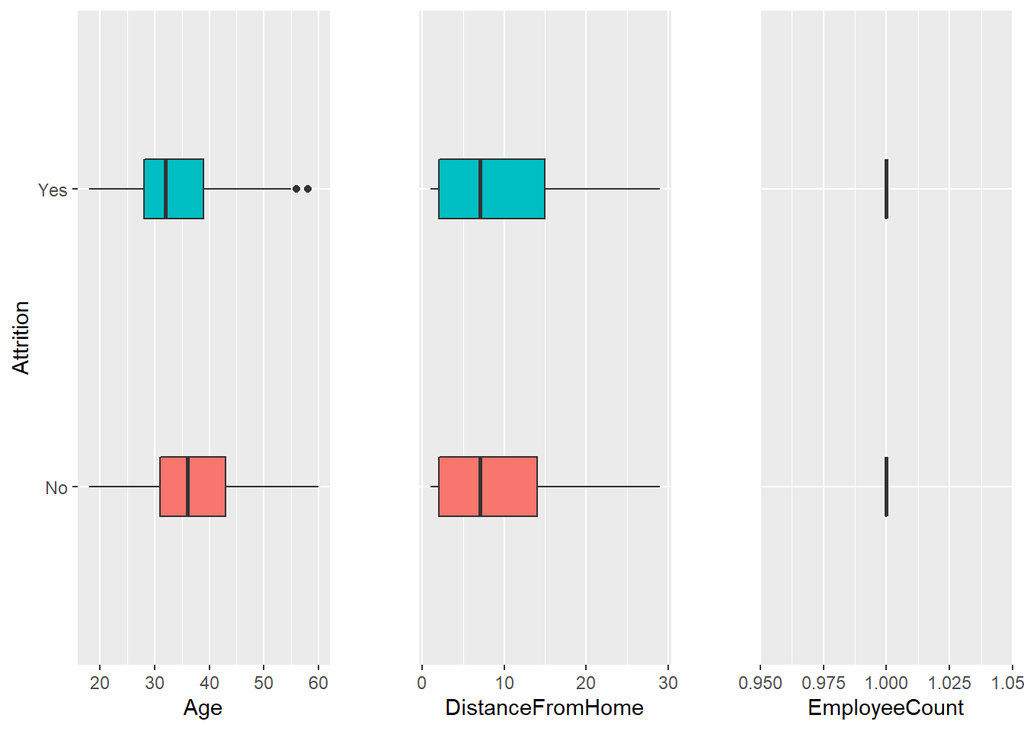

```r
box_theme<- theme(axis.line=element_blank(),axis.title=element_blank(),
                  axis.ticks=element_blank(), axis.text=element_blank())

box_theme_y<- theme(axis.line.y=element_blank(),axis.title.y=element_blank(),
                    axis.ticks.y=element_blank(), axis.text.y=element_blank(),
                    legend.position="none")

plot_grid(ggplot(final_data, aes(x=Attrition,y=Age, fill=Attrition))+ geom_boxplot(width=0.2)+
            coord_flip() +theme(legend.position="none"),
          ggplot(final_data, aes(x=Attrition,y=DistanceFromHome, fill=Attrition))+ geom_boxplot(width=0.2)+
            coord_flip() + box_theme_y,
          ggplot(final_data, aes(x=Attrition,y=EmployeeCount, fill=Attrition))+ geom_boxplot(width=0.2)+
            coord_flip() + box_theme_y,
          align = "v",nrow = 1)
```

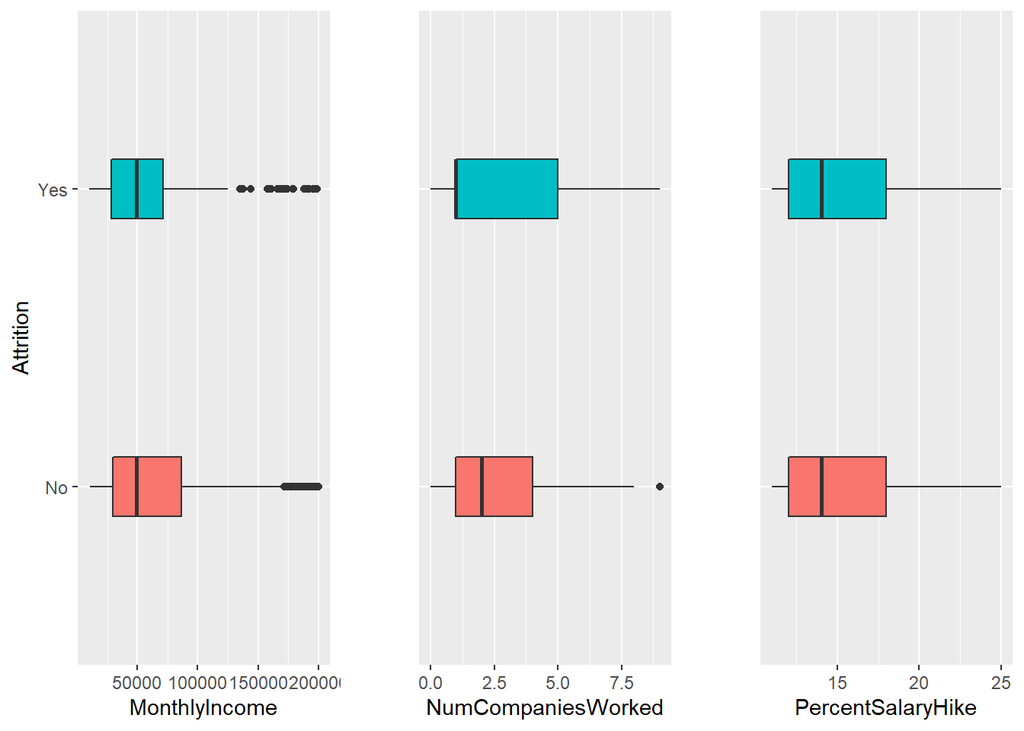

```r
plot_grid(ggplot(final_data, aes(x=Attrition,y=MonthlyIncome, fill=Attrition))+ geom_boxplot(width=0.2)+
            coord_flip() +theme(legend.position="none"),
          ggplot(final_data, aes(x=Attrition,y=NumCompaniesWorked, fill=Attrition))+ geom_boxplot(width=0.2)+
            coord_flip() + box_theme_y,
          ggplot(final_data, aes(x=Attrition,y=PercentSalaryHike, fill=Attrition))+ geom_boxplot(width=0.2)+
            coord_flip() + box_theme_y,
          align = "v",nrow = 1)
```

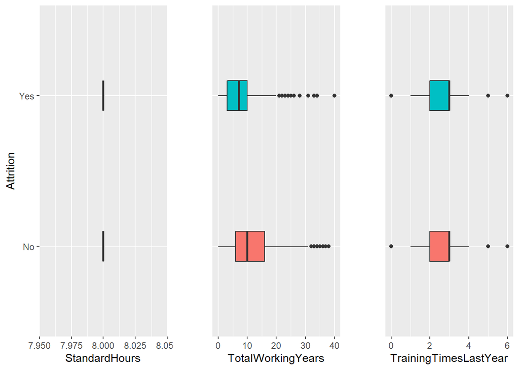

```r
plot_grid(ggplot(final_data, aes(x=Attrition,y=StandardHours, fill=Attrition))+ geom_boxplot(width=0.2)+
            coord_flip() +theme(legend.position="none"),
          ggplot(final_data, aes(x=Attrition,y=TotalWorkingYears, fill=Attrition))+ geom_boxplot(width=0.2)+
            coord_flip() + box_theme_y,
          ggplot(final_data, aes(x=Attrition,y=TrainingTimesLastYear, fill=Attrition))+ geom_boxplot(width=0.2)+
            coord_flip() + box_theme_y,
          align = "v",nrow = 1)
```

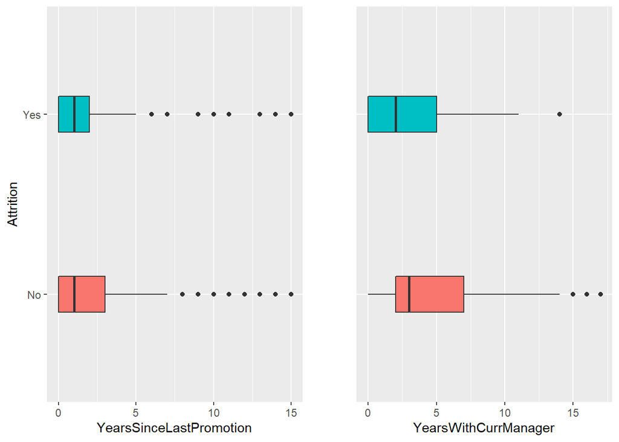

```r
plot_grid(ggplot(final_data, aes(x=Attrition,y=YearsSinceLastPromotion, fill=Attrition))+ geom_boxplot(width=0.2)+
            coord_flip() +theme(legend.position="none"),
          ggplot(final_data, aes(x=Attrition,y=YearsWithCurrManager, fill=Attrition))+ geom_boxplot(width=0.2)+
            coord_flip() + box_theme_y,
          align = "v",nrow = 1)
```

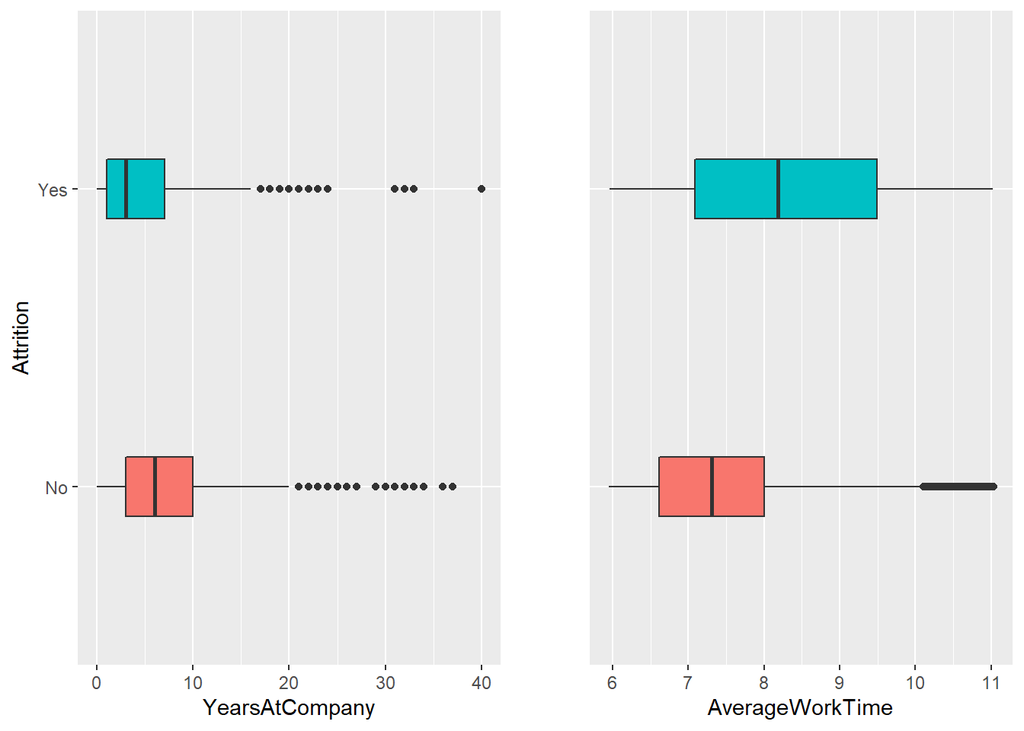

```r
plot_grid(ggplot(final_data, aes(x=Attrition,y=YearsAtCompany, fill=Attrition))+ geom_boxplot(width=0.2)+
            coord_flip() +theme(legend.position="none"),
          ggplot(final_data, aes(x=Attrition,y=AverageWorkTime, fill=Attrition))+ geom_boxplot(width=0.2)+
            coord_flip() + box_theme_y,
          align = "v",nrow = 1)
```

Distribution of Attrition in factor Variables

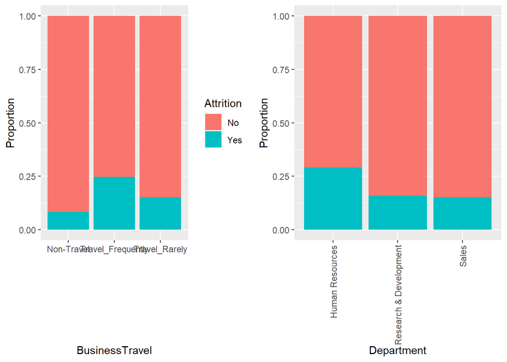

```r
bar_theme1<- theme(axis.text.x = element_text(angle = 90, hjust = 1, vjust = 0.5),
                   legend.position="none")

plot_grid(ggplot(final_data, aes(x=BusinessTravel,fill=Attrition))
          + geom_bar(position = position_fill())+ labs(y="Proportion"),
          ggplot(final_data, aes(x=Department,fill=Attrition))
          + geom_bar(position = position_fill())+ labs(y="Proportion")
          + bar_theme1, align = "h")
```

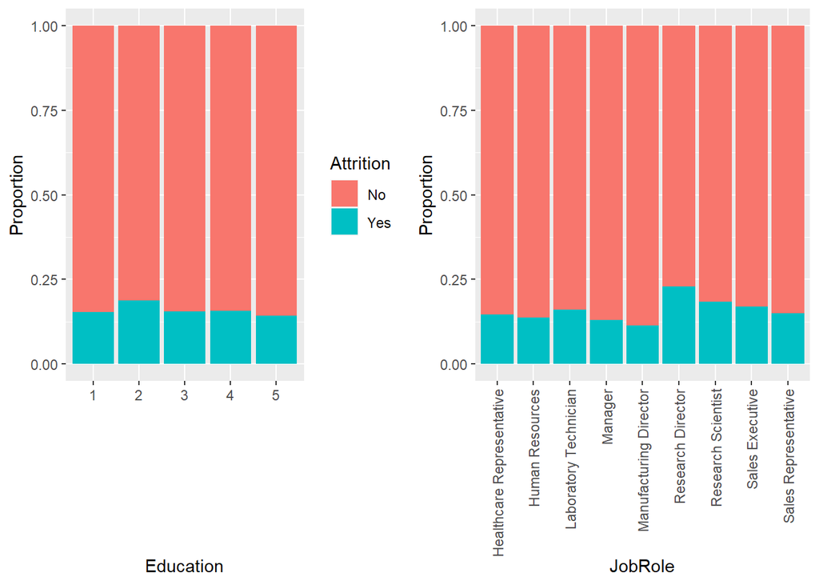

```r
plot_grid(ggplot(final_data, aes(x=Education,fill=Attrition))
          + geom_bar(position = position_fill())+ labs(y="Proportion"),
          ggplot(final_data, aes(x=JobRole,fill=Attrition))
          + geom_bar(position = position_fill())+ labs(y="Proportion")
          + bar_theme1, align = "h")
```

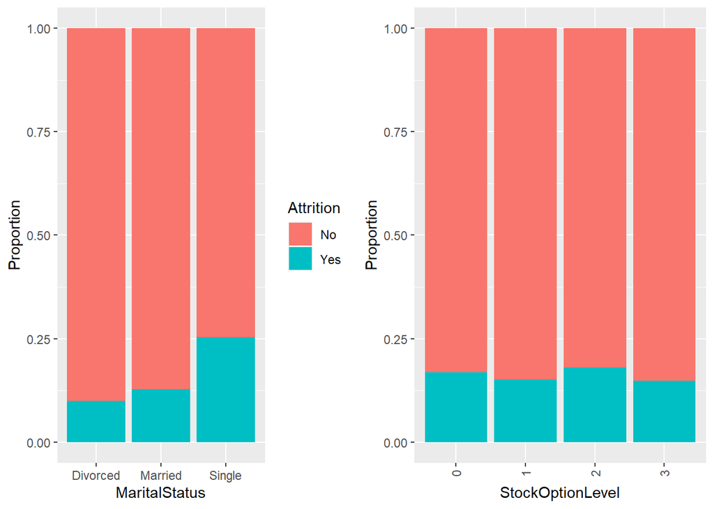

```r
plot_grid(ggplot(final_data, aes(x=MaritalStatus,fill=Attrition))
          + geom_bar(position = position_fill())+ labs(y="Proportion"),
          ggplot(final_data, aes(x=StockOptionLevel,fill=Attrition))
          + geom_bar(position = position_fill())+ labs(y="Proportion")
          + bar_theme1, align = "h")
```

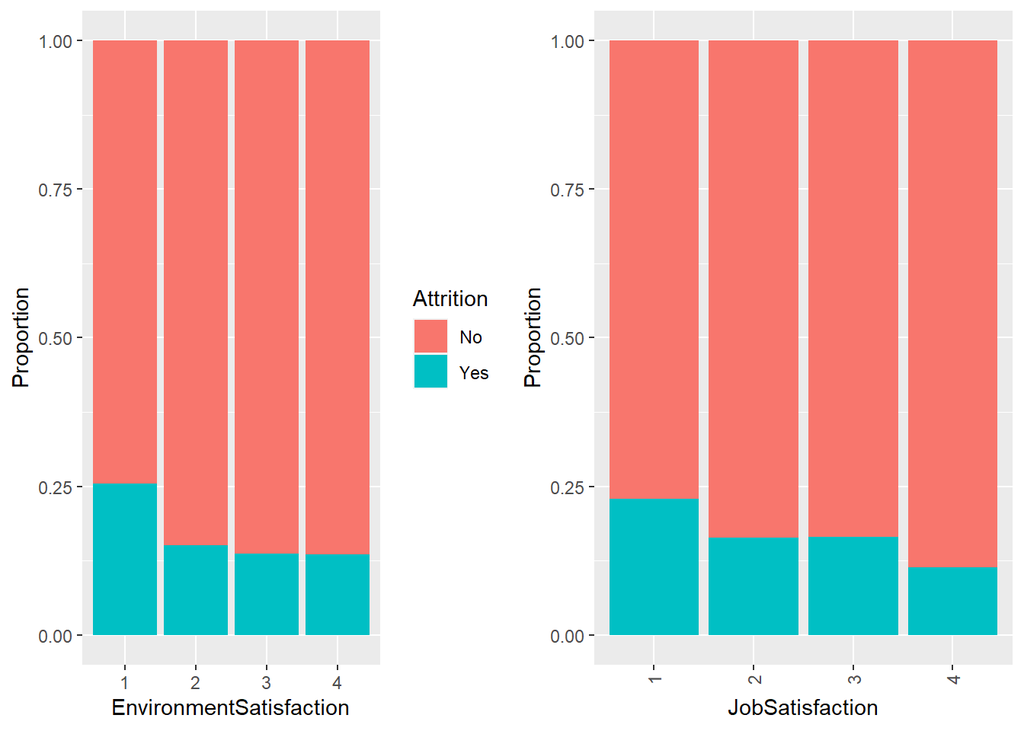

```r
plot_grid(ggplot(final_data, aes(x=EnvironmentSatisfaction,fill=Attrition))
          + geom_bar(position = position_fill())+ labs(y="Proportion"),
          ggplot(final_data, aes(x=JobSatisfaction,fill=Attrition))
          + geom_bar(position = position_fill())+ labs(y="Proportion")
          + bar_theme1, align = "h")
```

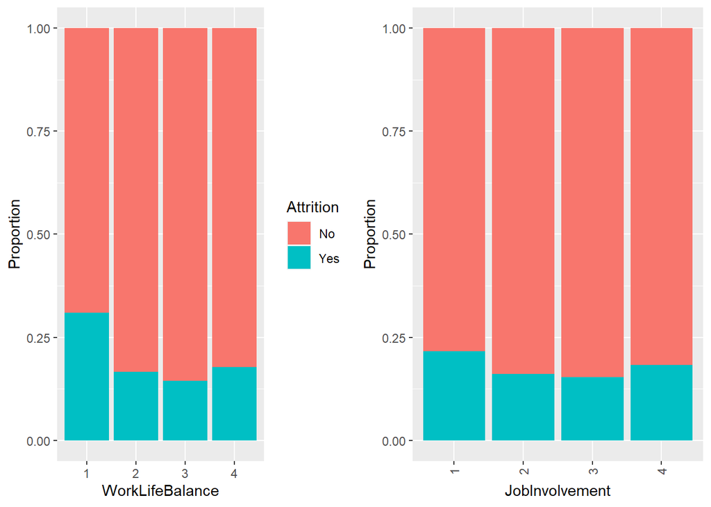

```r
plot_grid(ggplot(final_data, aes(x=WorkLifeBalance,fill=Attrition))
          + geom_bar(position = position_fill())+ labs(y="Proportion"),
          ggplot(final_data, aes(x=JobInvolvement,fill=Attrition))
          + geom_bar(position = position_fill())+ labs(y="Proportion")
          + bar_theme1, align = "h")
```

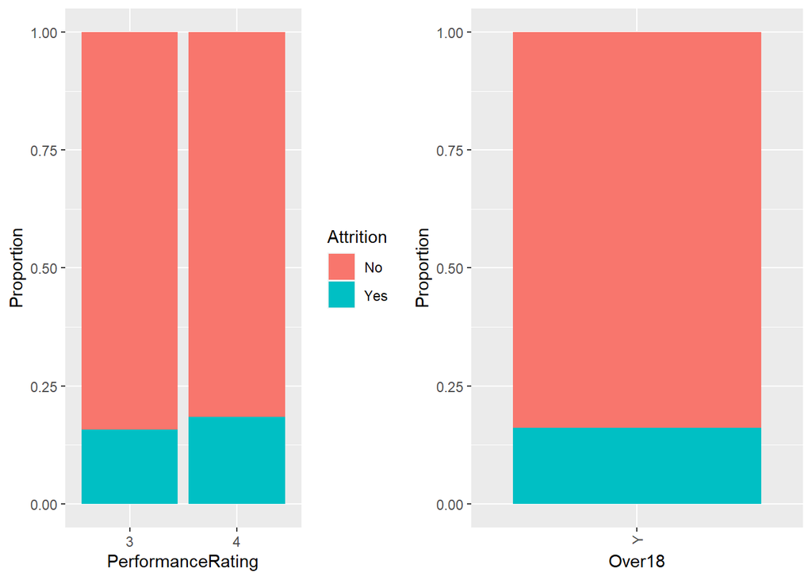

```r
plot_grid(ggplot(final_data, aes(x=PerformanceRating,fill=Attrition))
          + geom_bar(position = position_fill())+ labs(y="Proportion"),
          ggplot(final_data, aes(x=Over18,fill=Attrition))
          + geom_bar(position = position_fill())+ labs(y="Proportion")
          + bar_theme1, align = "h")
```

Normalising continuous features

creating a dataframe of numerical features

```r
INTEGER_VARIABLES <- lapply(final_data, class) == "integer" | lapply(final_data, class) == "numeric"
attrition_data_num<- final_data[, INTEGER_VARIABLES]
```

Standardising all numerical features

```r
attrition_data_stand<- data.frame(sapply(attrition_data_num,
                                         function(x) scale(x)))
```

Remove StandardHours because it contains NaN only

```r
attrition_data_stand$StandardHours <- NULL
```

Creating a dataframe of categorical features

```r
attrition_data_fact<- final_data[, FACTOR_VARIABLES]
```

Remove Over18 because it has only one category

```r
attrition_data_fact$Over18<-NULL
```

Creating dummy variables for factor attributes

```r
dummies<- data.frame(sapply(attrition_data_fact,
                            function(x) data.frame(model.matrix(~x-1,data =attrition_data_fact))[,-1]))
```

Converting target variable attrition from No/Yes character to factorwith levels 0/1

```r
dummies$Attrition<- as.numeric(dummies$Attrition)
```

Checking attrition rate of employees

```r
attrition_rate <- sum(dummies$Attrition)/nrow(dummies)
attrition_rate
```

```
## [1] 0.1616279
```

Final dataset

```r
attrition_final<- cbind(attrition_data_stand,dummies)
View(attrition_final)
```

Remove EmployeeCount because it contains NaN only

```r
attrition_final$EmployeeCount<-NULL
```

Splitting the data between train and test

```r
set.seed(1)

indices = sample.split(attrition_final$Attrition, SplitRatio = 0.7)

train = attrition_final[indices,]

test = attrition_final[!(indices),]
```

## Logistic Regression:

Initial model

```r
model_1 = glm(Attrition ~ ., data = train, family = "binomial")
summary(model_1)
```

```
##
## Call:
## glm(formula = Attrition ~ ., family = "binomial", data = train)
##
## Deviance Residuals:
##     Min       1Q   Median       3Q      Max
## -1.7471  -0.5506  -0.3109  -0.1382   3.8039
##
## Coefficients:
##                                     Estimate Std. Error z value Pr(>|z|)
## (Intercept)                         0.461262   0.604296   0.763 0.445282
## AverageWorkTime                     0.644883   0.056134  11.488  < 2e-16 ***
## Age                                -0.326488   0.083859  -3.893 9.89e-05 ***
## DistanceFromHome                    0.003159   0.059628   0.053 0.957753
## MonthlyIncome                      -0.026768   0.061323  -0.437 0.662461
## NumCompaniesWorked                  0.364183   0.064394   5.656 1.55e-08 ***
## PercentSalaryHike                   0.019730   0.092151   0.214 0.830462
## TotalWorkingYears                  -0.835099   0.137446  -6.076 1.23e-09 ***
## TrainingTimesLastYear              -0.193929   0.061384  -3.159 0.001582 **
## YearsAtCompany                      0.424307   0.151278   2.805 0.005035 **
## YearsSinceLastPromotion             0.617493   0.087296   7.074 1.51e-12 ***
## YearsWithCurrManager               -0.759396   0.109191  -6.955 3.53e-12 ***
## BusinessTravel.xTravel_Frequently   1.495408   0.270261   5.533 3.14e-08 ***
## BusinessTravel.xTravel_Rarely       0.761235   0.248516   3.063 0.002190 **
## Department.xResearch...Development -0.987954   0.335206  -2.947 0.003206 **
## Department.xSales                  -1.105248   0.354042  -3.122 0.001797 **
## Education.x2                        0.073996   0.215247   0.344 0.731018
## Education.x3                       -0.037526   0.198498  -0.189 0.850054
## Education.x4                       -0.044390   0.207784  -0.214 0.830833
## Education.x5                       -0.556206   0.387665  -1.435 0.151356
## EducationField.xLife.Sciences      -0.428098   0.470424  -0.910 0.362809
## EducationField.xMarketing          -0.622188   0.519385  -1.198 0.230944
## EducationField.xMedical            -0.533358   0.469640  -1.136 0.256094
## EducationField.xOther              -0.519844   0.526089  -0.988 0.323090
## EducationField.xTechnical.Degree   -0.576881   0.497254  -1.160 0.245994
## Gender                              0.160589   0.121979   1.317 0.187995
## JobLevel.x2                         0.146125   0.138653   1.054 0.291932
## JobLevel.x3                        -0.002193   0.180817  -0.012 0.990324
## JobLevel.x4                         0.016597   0.239292   0.069 0.944703
## JobLevel.x5                        -0.409550   0.309120  -1.325 0.185207
```

[output cut: 21 more lines]

```
## WorkLifeBalance.x4                 -1.156794   0.266554  -4.340 1.43e-05 ***
## JobInvolvement.x2                  -0.008279   0.256369  -0.032 0.974237
## JobInvolvement.x3                  -0.349835   0.239397  -1.461 0.143929
## JobInvolvement.x4                   0.197699   0.285562   0.692 0.488740
## PerformanceRating                  -0.020460   0.251809  -0.081 0.935242
## ---
## Signif. codes:  0 '***' 0.001 '**' 0.01 '*' 0.05 '.' 0.1 ' ' 1
##
## (Dispersion parameter for binomial family taken to be 1)
##
##     Null deviance: 2661.4  on 3009  degrees of freedom
## Residual deviance: 1985.1  on 2954  degrees of freedom
## AIC: 2097.1
##
## Number of Fisher Scoring iterations: 6
```

Stepwise selection

```r
library("MASS")
model_2<- stepAIC(model_1, direction="both")
```

```
## Start:  AIC=2097.13
## Attrition ~ AverageWorkTime + Age + DistanceFromHome + MonthlyIncome +
##     NumCompaniesWorked + PercentSalaryHike + TotalWorkingYears +
##     TrainingTimesLastYear + YearsAtCompany + YearsSinceLastPromotion +
##     YearsWithCurrManager + BusinessTravel.xTravel_Frequently +
##     BusinessTravel.xTravel_Rarely + Department.xResearch...Development +
##     Department.xSales + Education.x2 + Education.x3 + Education.x4 +
##     Education.x5 + EducationField.xLife.Sciences + EducationField.xMarketing +
##     EducationField.xMedical + EducationField.xOther + EducationField.xTechnical.Degree +
##     Gender + JobLevel.x2 + JobLevel.x3 + JobLevel.x4 + JobLevel.x5 +
##     JobRole.xHuman.Resources + JobRole.xLaboratory.Technician +
##     JobRole.xManager + JobRole.xManufacturing.Director + JobRole.xResearch.Director +
##     JobRole.xResearch.Scientist + JobRole.xSales.Executive +
##     JobRole.xSales.Representative + MaritalStatus.xMarried +
##     MaritalStatus.xSingle + StockOptionLevel.x1 + StockOptionLevel.x2 +
##     StockOptionLevel.x3 + EnvironmentSatisfaction.x2 + EnvironmentSatisfaction.x3 +
##     EnvironmentSatisfaction.x4 + JobSatisfaction.x2 + JobSatisfaction.x3 +
##     JobSatisfaction.x4 + WorkLifeBalance.x2 + WorkLifeBalance.x3 +
##     WorkLifeBalance.x4 + JobInvolvement.x2 + JobInvolvement.x3 +
##     JobInvolvement.x4 + PerformanceRating
##
##                                      Df Deviance    AIC
## - JobLevel.x3                         1   1985.1 2095.1
## - JobInvolvement.x2                   1   1985.1 2095.1
## - DistanceFromHome                    1   1985.1 2095.1
## - JobLevel.x4                         1   1985.1 2095.1
## - PerformanceRating                   1   1985.1 2095.1
## - StockOptionLevel.x3                 1   1985.2 2095.2
## - Education.x3                        1   1985.2 2095.2
## - Education.x4                        1   1985.2 2095.2
## - PercentSalaryHike                   1   1985.2 2095.2
## - Education.x2                        1   1985.2 2095.2
## - JobRole.xHuman.Resources            1   1985.3 2095.3
## - JobRole.xSales.Representative       1   1985.3 2095.3
## - StockOptionLevel.x2                 1   1985.3 2095.3
## - MonthlyIncome                       1   1985.3 2095.3
## - StockOptionLevel.x1                 1   1985.4 2095.4
## - JobRole.xResearch.Scientist         1   1985.6 2095.6
## - JobInvolvement.x4                   1   1985.6 2095.6
## - EducationField.xLife.Sciences       1   1986.0 2096.0
```

[output cut: 2034 more lines]

```
## - WorkLifeBalance.x4                  1   2017.1 2073.1
## - Department.xResearch...Development  1   2026.0 2081.9
## - Department.xSales                   1   2029.4 2085.4
## - NumCompaniesWorked                  1   2029.7 2085.7
## - EnvironmentSatisfaction.x2          1   2030.5 2086.6
## - WorkLifeBalance.x3                  1   2032.6 2088.6
## - BusinessTravel.xTravel_Frequently   1   2033.5 2089.5
## - EnvironmentSatisfaction.x3          1   2039.4 2095.4
## - TotalWorkingYears                   1   2042.1 2098.1
## - JobSatisfaction.x4                  1   2043.1 2099.1
## - YearsWithCurrManager                1   2047.8 2103.8
## - YearsSinceLastPromotion             1   2048.3 2104.3
## - EnvironmentSatisfaction.x4          1   2058.2 2114.2
## - MaritalStatus.xSingle               1   2074.1 2130.1
## - AverageWorkTime                     1   2140.3 2196.3
```

```r
summary(model_2)
```

```
##
## Call:
## glm(formula = Attrition ~ AverageWorkTime + Age + NumCompaniesWorked +
##     TotalWorkingYears + TrainingTimesLastYear + YearsAtCompany +
##     YearsSinceLastPromotion + YearsWithCurrManager + BusinessTravel.xTravel_Frequently +
##     BusinessTravel.xTravel_Rarely + Department.xResearch...Development +
##     Department.xSales + Education.x5 + JobLevel.x5 + JobRole.xManager +
##     JobRole.xManufacturing.Director + JobRole.xResearch.Director +
##     MaritalStatus.xSingle + EnvironmentSatisfaction.x2 + EnvironmentSatisfaction.x3 +
##     EnvironmentSatisfaction.x4 + JobSatisfaction.x2 + JobSatisfaction.x3 +
##     JobSatisfaction.x4 + WorkLifeBalance.x2 + WorkLifeBalance.x3 +
##     WorkLifeBalance.x4 + JobInvolvement.x3, family = "binomial",
##     data = train)
##
## Deviance Residuals:
##     Min       1Q   Median       3Q      Max
## -1.7446  -0.5555  -0.3107  -0.1404   3.8950
##
## Coefficients:
##                                    Estimate Std. Error z value Pr(>|z|)
## (Intercept)                         0.74261    0.40885   1.816 0.069320 .
## AverageWorkTime                     0.64361    0.05513  11.675  < 2e-16 ***
## Age                                -0.32243    0.08145  -3.958 7.54e-05 ***
## NumCompaniesWorked                  0.35439    0.06266   5.656 1.55e-08 ***
## TotalWorkingYears                  -0.83279    0.13521  -6.159 7.32e-10 ***
## TrainingTimesLastYear              -0.19221    0.05927  -3.243 0.001184 **
## YearsAtCompany                      0.42014    0.14927   2.815 0.004884 **
## YearsSinceLastPromotion             0.60499    0.08674   6.975 3.06e-12 ***
## YearsWithCurrManager               -0.76142    0.10745  -7.086 1.38e-12 ***
## BusinessTravel.xTravel_Frequently   1.45808    0.26651   5.471 4.47e-08 ***
## BusinessTravel.xTravel_Rarely       0.74851    0.24607   3.042 0.002351 **
## Department.xResearch...Development -1.28083    0.23554  -5.438 5.40e-08 ***
## Department.xSales                  -1.42974    0.24942  -5.732 9.91e-09 ***
## Education.x5                       -0.58299    0.34674  -1.681 0.092693 .
## JobLevel.x5                        -0.50140    0.29331  -1.709 0.087373 .
## JobRole.xManager                   -0.70583    0.27130  -2.602 0.009277 **
## JobRole.xManufacturing.Director    -0.75818    0.21972  -3.451 0.000559 ***
## JobRole.xResearch.Director          0.58424    0.24062   2.428 0.015181 *
## MaritalStatus.xSingle               1.02865    0.11870   8.666  < 2e-16 ***
## EnvironmentSatisfaction.x2         -0.98019    0.17611  -5.566 2.61e-08 ***
## EnvironmentSatisfaction.x3         -1.01690    0.16010  -6.352 2.13e-10 ***
## EnvironmentSatisfaction.x4         -1.22628    0.16076  -7.628 2.38e-14 ***
## JobSatisfaction.x2                 -0.54596    0.17553  -3.110 0.001869 **
## JobSatisfaction.x3                 -0.55906    0.15877  -3.521 0.000430 ***
## JobSatisfaction.x4                 -1.11703    0.16848  -6.630 3.36e-11 ***
## WorkLifeBalance.x2                 -0.87719    0.22358  -3.923 8.73e-05 ***
## WorkLifeBalance.x3                 -1.25923    0.20783  -6.059 1.37e-09 ***
## WorkLifeBalance.x4                 -1.12501    0.26124  -4.306 1.66e-05 ***
## JobInvolvement.x3                  -0.36719    0.11792  -3.114 0.001846 **
## ---
## Signif. codes:  0 '***' 0.001 '**' 0.01 '*' 0.05 '.' 0.1 ' ' 1
##
## (Dispersion parameter for binomial family taken to be 1)
##
##     Null deviance: 2661.4  on 3009  degrees of freedom
## Residual deviance: 1998.5  on 2981  degrees of freedom
## AIC: 2056.5
##
## Number of Fisher Scoring iterations: 6
```

Removing multicollinearity through VIF check

```r
library(car)
vif(model_2)
```

```
##                    AverageWorkTime                                Age
##                           1.071130                           1.834064
##                 NumCompaniesWorked                  TotalWorkingYears
##                           1.375050                           3.621909
##              TrainingTimesLastYear                     YearsAtCompany
##                           1.036072                           5.115686
##            YearsSinceLastPromotion               YearsWithCurrManager
##                           2.316085                           2.655559
##  BusinessTravel.xTravel_Frequently      BusinessTravel.xTravel_Rarely
##                           3.996326                           3.921496
## Department.xResearch...Development                  Department.xSales
##                           3.909029                           3.903241
##                       Education.x5                        JobLevel.x5
##                           1.047270                           1.047187
##                   JobRole.xManager    JobRole.xManufacturing.Director
##                           1.041169                           1.037026
##         JobRole.xResearch.Director              MaritalStatus.xSingle
##                           1.031694                           1.069835
##         EnvironmentSatisfaction.x2         EnvironmentSatisfaction.x3
##                           1.469453                           1.579655
##         EnvironmentSatisfaction.x4                 JobSatisfaction.x2
##                           1.605306                           1.543896
##                 JobSatisfaction.x3                 JobSatisfaction.x4
##                           1.660344                           1.664108
##                 WorkLifeBalance.x2                 WorkLifeBalance.x3
##                           2.871458                           3.292701
##                 WorkLifeBalance.x4                  JobInvolvement.x3
##                           2.001578                           1.056693
```

Now we build models using different predictor variables based on VIF scores

```r
final_model<- glm(formula = Attrition ~ AverageWorkTime + Age + NumCompaniesWorked +
                  TotalWorkingYears + TrainingTimesLastYear + YearsSinceLastPromotion +
                  YearsWithCurrManager + BusinessTravel.xTravel_Frequently +
                  BusinessTravel.xTravel_Rarely + JobRole.xManufacturing.Director +
                  JobRole.xResearch.Director + JobRole.xSales.Executive +
                  MaritalStatus.xSingle + EnvironmentSatisfaction.x2 +
                  EnvironmentSatisfaction.x3 + EnvironmentSatisfaction.x4 +
                  JobSatisfaction.x2 + JobSatisfaction.x3 + JobSatisfaction.x4 +
                  WorkLifeBalance.x2 + WorkLifeBalance.x3 + WorkLifeBalance.x4,
                  family = "binomial", data = train)
summary(final_model)
```

```
##
## Call:
## glm(formula = Attrition ~ AverageWorkTime + Age + NumCompaniesWorked +
##     TotalWorkingYears + TrainingTimesLastYear + YearsSinceLastPromotion +
##     YearsWithCurrManager + BusinessTravel.xTravel_Frequently +
##     BusinessTravel.xTravel_Rarely + JobRole.xManufacturing.Director +
##     JobRole.xResearch.Director + JobRole.xSales.Executive + MaritalStatus.xSingle +
##     EnvironmentSatisfaction.x2 + EnvironmentSatisfaction.x3 +
##     EnvironmentSatisfaction.x4 + JobSatisfaction.x2 + JobSatisfaction.x3 +
##     JobSatisfaction.x4 + WorkLifeBalance.x2 + WorkLifeBalance.x3 +
##     WorkLifeBalance.x4, family = "binomial", data = train)
##
## Deviance Residuals:
##     Min       1Q   Median       3Q      Max
## -1.9826  -0.5673  -0.3385  -0.1607   3.8949
##
## Coefficients:
##                                   Estimate Std. Error z value Pr(>|z|)
## (Intercept)                       -0.90143    0.32519  -2.772 0.005572 **
## AverageWorkTime                    0.64482    0.05441  11.850  < 2e-16 ***
## Age                               -0.31892    0.07969  -4.002 6.29e-05 ***
## NumCompaniesWorked                 0.28336    0.05951   4.761 1.92e-06 ***
## TotalWorkingYears                 -0.61395    0.11038  -5.562 2.67e-08 ***
## TrainingTimesLastYear             -0.19420    0.05836  -3.328 0.000875 ***
## YearsSinceLastPromotion            0.65367    0.07976   8.195 2.50e-16 ***
## YearsWithCurrManager              -0.58381    0.08966  -6.512 7.43e-11 ***
## BusinessTravel.xTravel_Frequently  1.39090    0.26129   5.323 1.02e-07 ***
## BusinessTravel.xTravel_Rarely      0.77677    0.24267   3.201 0.001370 **
## JobRole.xManufacturing.Director   -0.57271    0.21838  -2.623 0.008729 **
## JobRole.xResearch.Director         0.66535    0.23872   2.787 0.005317 **
## JobRole.xSales.Executive           0.25193    0.13777   1.829 0.067460 .
## MaritalStatus.xSingle              0.99222    0.11647   8.519  < 2e-16 ***
## EnvironmentSatisfaction.x2        -0.92612    0.17274  -5.361 8.26e-08 ***
## EnvironmentSatisfaction.x3        -0.94663    0.15625  -6.058 1.38e-09 ***
## EnvironmentSatisfaction.x4        -1.17241    0.15834  -7.405 1.32e-13 ***
## JobSatisfaction.x2                -0.46374    0.17193  -2.697 0.006993 **
## JobSatisfaction.x3                -0.53469    0.15573  -3.434 0.000596 ***
## JobSatisfaction.x4                -1.08596    0.16570  -6.554 5.61e-11 ***
## WorkLifeBalance.x2                -0.92943    0.22280  -4.172 3.02e-05 ***
## WorkLifeBalance.x3                -1.26876    0.20638  -6.148 7.86e-10 ***
## WorkLifeBalance.x4                -1.11457    0.25986  -4.289 1.79e-05 ***
## ---
## Signif. codes:  0 '***' 0.001 '**' 0.01 '*' 0.05 '.' 0.1 ' ' 1
##
## (Dispersion parameter for binomial family taken to be 1)
##
##     Null deviance: 2661.4  on 3009  degrees of freedom
## Residual deviance: 2052.6  on 2987  degrees of freedom
## AIC: 2098.6
##
## Number of Fisher Scoring iterations: 6
```

## Model Evaluation

```r
test_pred = predict(final_model, type = "response",
                              newdata = test)


summary(test_pred)
```

```
##      Min.   1st Qu.    Median      Mean   3rd Qu.      Max.
## 0.0005095 0.0408130 0.1021451 0.1706165 0.2418827 0.9563749
```

Let’s use the probability cutoff of 50%.

```r
test_pred_attrition <- factor(ifelse(test_pred >= 0.50, "Yes", "No"))
test_actual_attrition <- factor(ifelse(test$Attrition==1,"Yes","No"))

test_conf <- confusionMatrix(test_pred_attrition, test_actual_attrition, positive = "Yes")
test_conf
```

```
## Confusion Matrix and Statistics
##
##           Reference
## Prediction   No  Yes
##        No  1048  147
##        Yes   33   62
##
##                Accuracy : 0.8605
##                  95% CI : (0.8403, 0.8789)
##     No Information Rate : 0.838
##     P-Value [Acc > NIR] : 0.01438
##
##                   Kappa : 0.3412
##
##  Mcnemar's Test P-Value : < 2e-16
##
##             Sensitivity : 0.29665
##             Specificity : 0.96947
##          Pos Pred Value : 0.65263
##          Neg Pred Value : 0.87699
##              Prevalence : 0.16202
##          Detection Rate : 0.04806
##    Detection Prevalence : 0.07364
##       Balanced Accuracy : 0.63306
##
##        'Positive' Class : Yes
##
```

We can see that the sensitivity is very low. So we will choose a different cutoff value.

```r
perform_fn <- function(cutoff)
{
  predicted_attrition <- factor(ifelse(test_pred >= cutoff, "Yes", "No"))
  conf <- confusionMatrix(predicted_attrition, test_actual_attrition, positive = "Yes")
  acc <- conf$overall[1]
  sens <- conf$byClass[1]
  spec <- conf$byClass[2]
  out <- t(as.matrix(c(sens, spec, acc)))
  colnames(out) <- c("sensitivity", "specificity", "accuracy")
  return(out)
}
```

Creating cutoff values from 0.01 to 0.80 for plotting and initiallizing a matrix of 100 X 3.

Summary of test probability

```r
summary(test_pred)
```

```
##      Min.   1st Qu.    Median      Mean   3rd Qu.      Max.
## 0.0005095 0.0408130 0.1021451 0.1706165 0.2418827 0.9563749
```

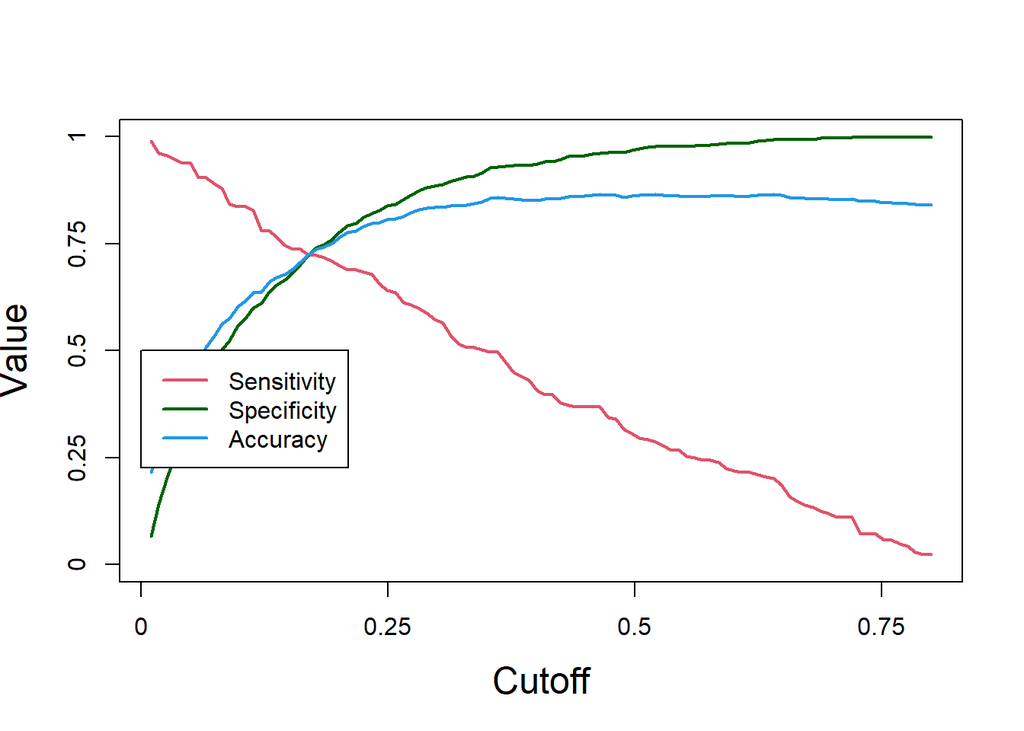

```r
s = seq(.01,.80,length=100)

OUT = matrix(0,100,3)


for(i in 1:100)
{
  OUT[i,] = perform_fn(s[i])
}


plot(s, OUT[,1],xlab="Cutoff",ylab="Value",cex.lab=1.5,cex.axis=1.5,ylim=c(0,1),type="l",lwd=2,axes=FALSE,col=2)
axis(1,seq(0,1,length=5),seq(0,1,length=5),cex.lab=1.5)
axis(2,seq(0,1,length=5),seq(0,1,length=5),cex.lab=1.5)
lines(s,OUT[,2],col="darkgreen",lwd=2)
lines(s,OUT[,3],col=4,lwd=2)
box()
legend(0,.50,col=c(2,"darkgreen",4,"darkred"),lwd=c(2,2,2,2),c("Sensitivity","Specificity","Accuracy"))
```

```r
cutoff <- s[which(abs(OUT[,1]-OUT[,2])<0.01)]

cutoff
```

```
## [1] 0.169596
```

Let’s choose a cutoff value of 0.194 for final model

```r
test_cutoff_attrition <- factor(ifelse(test_pred >=0.194, "Yes", "No"))

conf_final <- confusionMatrix(test_cutoff_attrition, test_actual_attrition, positive = "Yes")

acc <- conf_final$overall[1]

sens <- conf_final$byClass[1]

spec <- conf_final$byClass[2]

acc
```

```
##  Accuracy
## 0.7542636
```

```r
sens
```

```
## Sensitivity
##    0.708134
```

```r
spec
```

```
## Specificity
##   0.7631822
```

```r
test_cutoff_attrition <- ifelse(test_cutoff_attrition=="Yes",1,0)
test_actual_attrition <- ifelse(test_actual_attrition=="Yes",1,0)
```